# Climate Vulnerability Indicators for Salmon: A Quantitative Framework for Evaluating the Relative Vulnerability of Pacific Salmon Conservation Units

### vi. Cumulative threats to stream habitat (CT)

**Metric:** A composite index of threats from human activity to stream habitat, calculated using a normalized additive model that combines nine threat categories including flow alteration, in-stream habitat destruction, riparian disturbance, nutrients, pollution, and sedimentation. The indicator is calculated as the mean cumulative threat score across all accessible streams with modelled habitat potential in the CU boundary, weighted by stream segment length.

#### 45

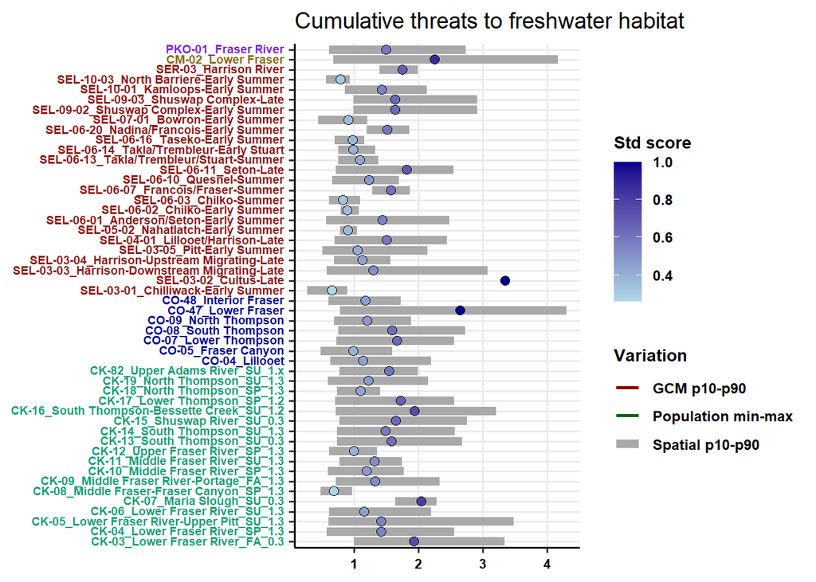

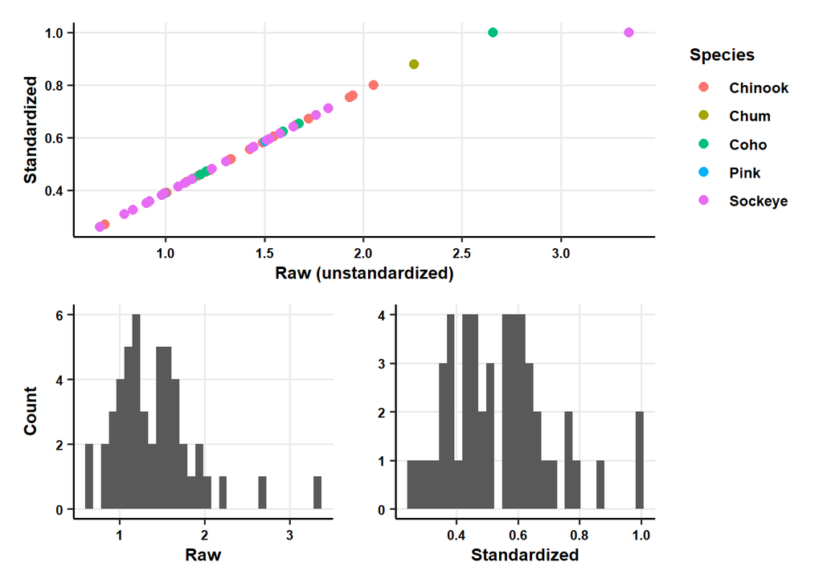

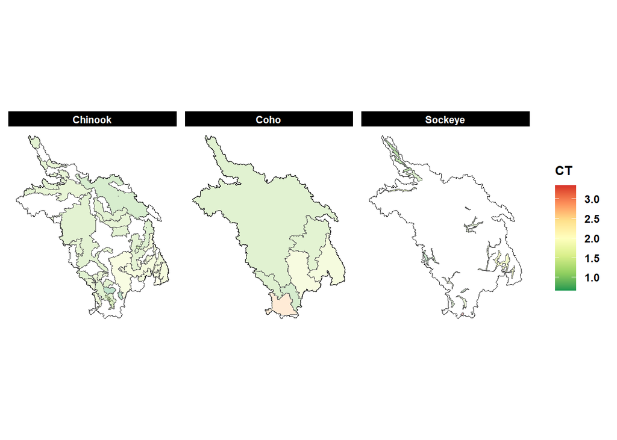

#### 85

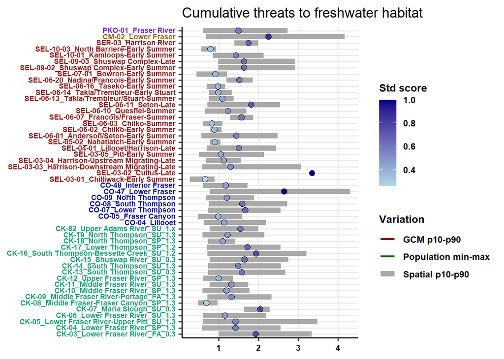

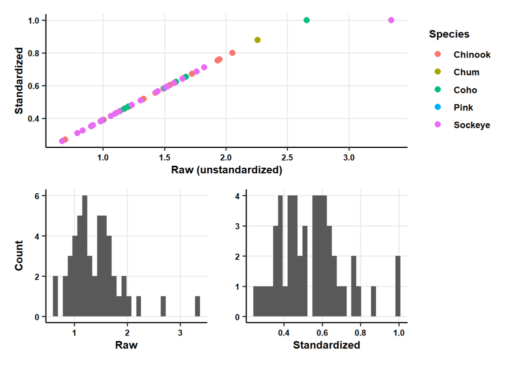

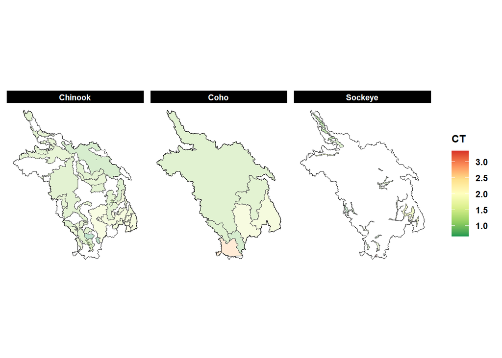

# Upstream Migration

Upstream migration indicators

| Abbreviation | Category | Description |
| --- | --- | --- |
| migrT | Upstream Migration | Projected temperature during upstream migration |
| migrQ | Upstream Migration | Proportional change in discharge during upstream migration |
| migrdist | Upstream Migration | Length of upstream migration |

#### Data Sources

**PCIC Variable Infiltration Capacity With Glaciers (VIC-GL) gridded model** - Dynamically downscaled projections of stream temperature and flow from 1980 to 2099 for gauged watersheds within British Columbia [https://pacificclimate.org/analysis-tools/salmon-climate-impacts-portal]  
**PSF CU-Specific Life History Timing** - timing of freshwater life history events for each CU used for run timing and spawn timing [https://datadryad.org/dataset/doi:10.5061/dryad.wm37pvmwx]

**NUSEDS (New Spawning Escapement Database)** - CU spawning sites used to determine migration end points [https://open.canada.ca/data/en/dataset/c48669a3-045b-400d-b730-48aafe8c5ee6]

#### Methods

Indicators for the upstream migration life stage represent changes to stream temperatures and flows, and distance to spawning sites. For each CU, a migration path from river mouth to each NUSEDS spawning sites was created using the BC Freshwater Atlas stream network. Migration distance for each path was calculated as the length of all stream segments from river mouth to spawning site, and averaged across all NuSEDS sites to get an average migration distance for each CU.

To estimate temperatures and flow during upstream migration, an upstream movement model was applied to stream segments within the migration path and used to subset days of the year and spatial grid cells from the VIC-GL model. The model began with stream segments within 100km of the river mouth at the start of run timing. The front end of this spatial subset was moved upstream at a rate equal to the distance to spawning sites divided by the number of days between spawn timing start and run timing start. This assumes that the spawn timing start coincides with arrival to the spawning sites. The tail end of the migration was modelled to arrive at the spawning grounds at the peak spawn date, and moved upstream from the river mouth at a rate equal to the distance to spawning sites divided by the number of days between spawn timing peak and run timing end.

### i. Projected temperature during migration

**Metric:** The average of water temperatures during the upstream migration across all years of the projection period (2041-2060 or 2081-2100) estimated along the migration path from river entry to spawning sites using an upstream migration model. The model uses a moving migration window to represent the thermal exposure of CUs starting at the river mouth on the run timing start date and terminating at spawning sites on the peak spawning date. Projections from representative concentration pathways (RCP) 4.5 and 8.5 are included with an ensemble mean calculated from six global climate models.

#### 45

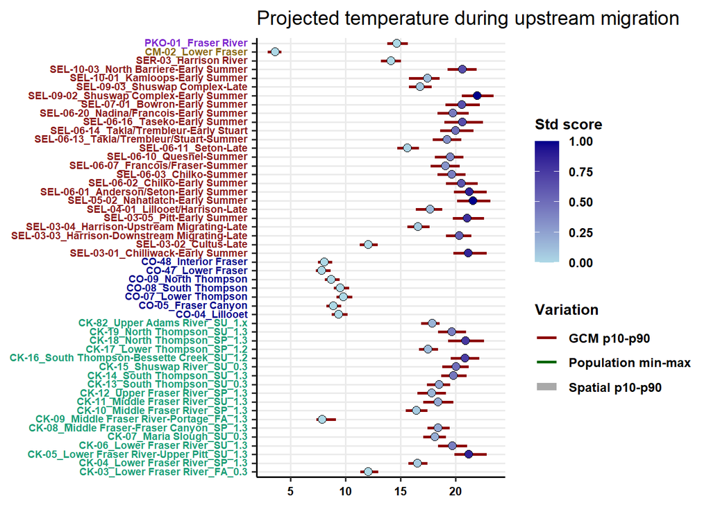

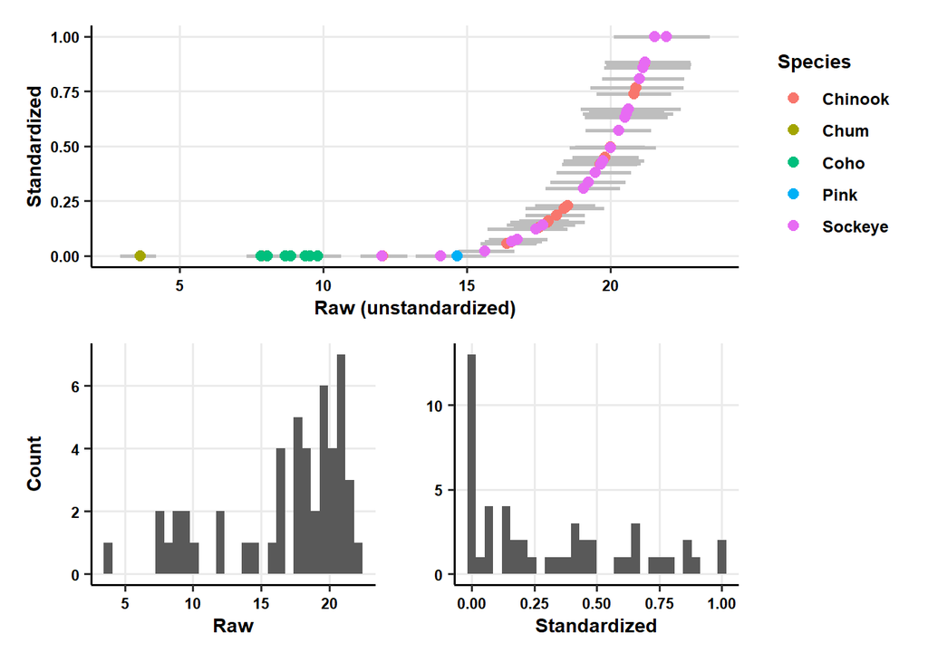

#### 85

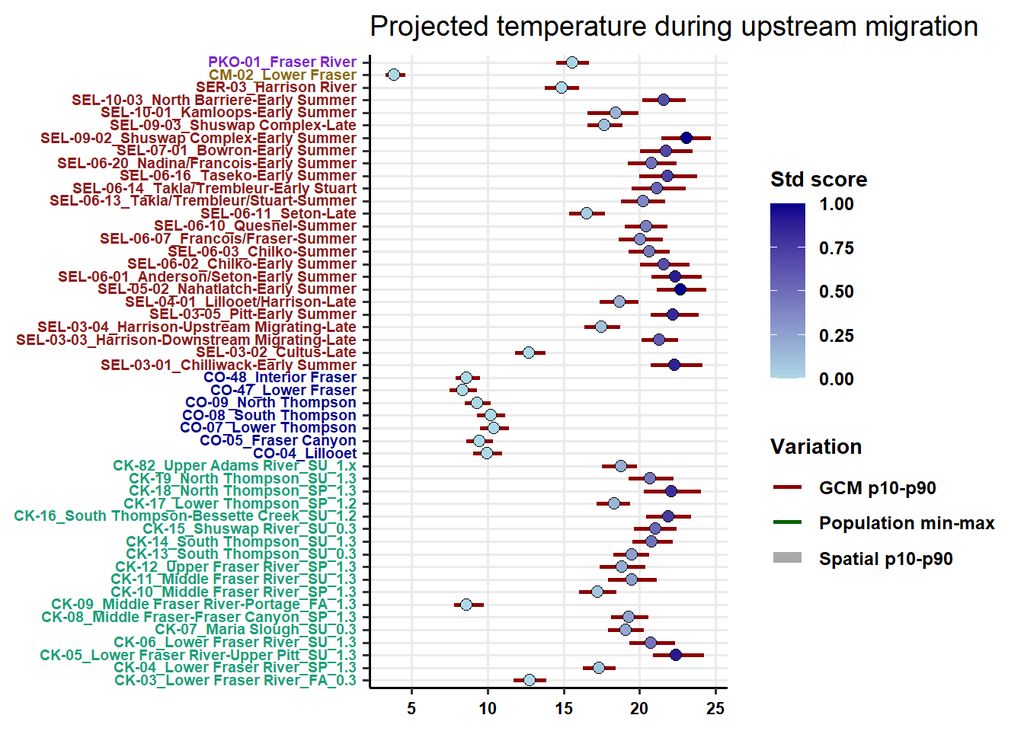

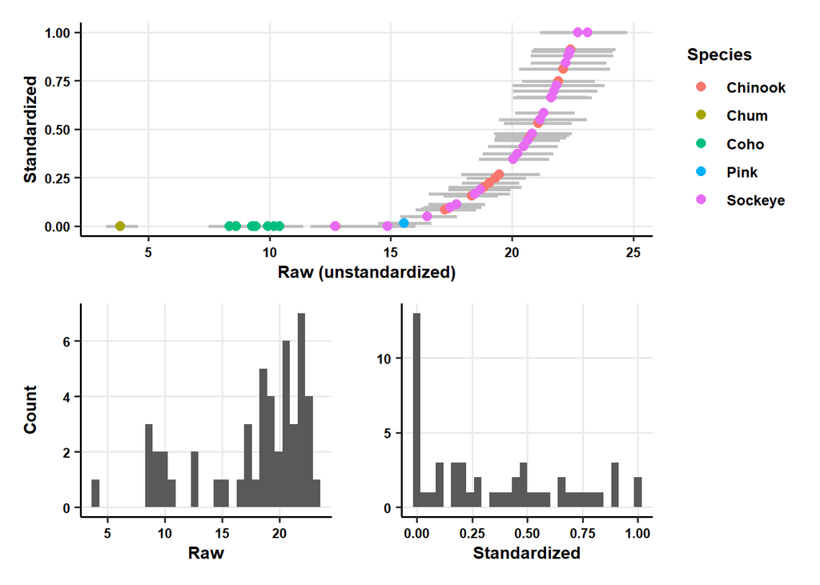

### ii. Proportional change in flow during upstream migration

**Metric:** The proportional change in flow during the upstream migration from the baseline period (1981-2000) to the projection period (2041-2060 or 2081-2100) estimated along the migration path from river entry to spawning sites using an upstream migration model. The model uses a moving migration window to represent the average flow experienced by CUs starting at the river mouth on the run timing start date and terminating at spawning sites on the peak spawning date. Projections from representative concentration pathways (RCP) 4.5 and 8.5 are included with an ensemble mean calculated from six global climate models.

#### 45

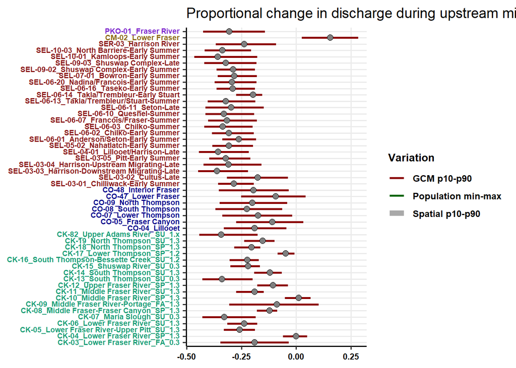

[figure not shown]

#### 85

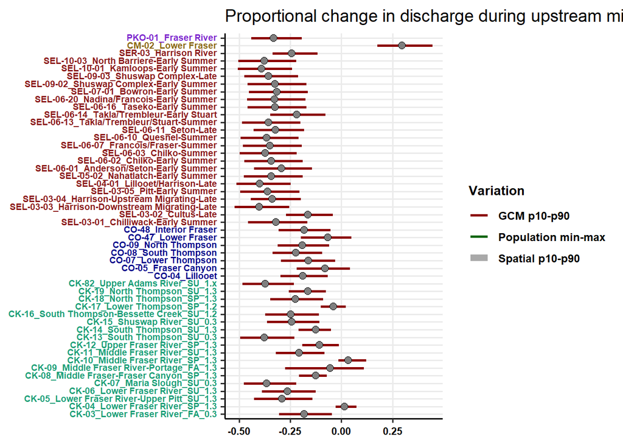

[figure not shown]

### iii. Upstream migration distance

**Metric:** The distance of the migration path from river mouth to spawning sites. For CUs with multiple spawning locations, the average of the migration distance to all spawning sites is used.

#### 45

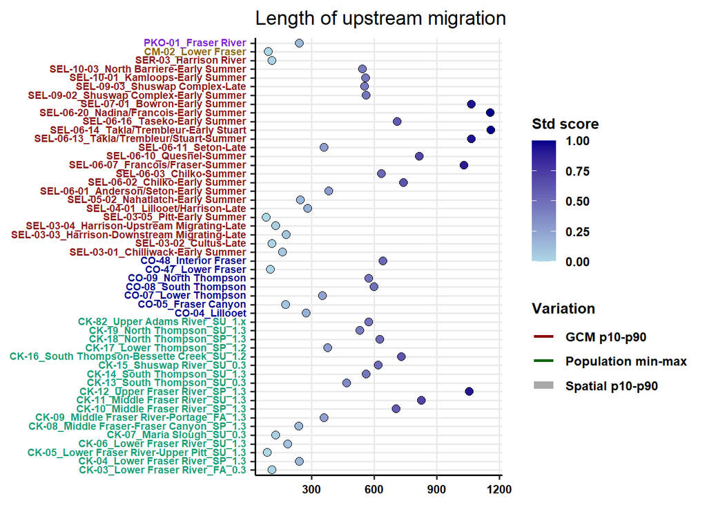

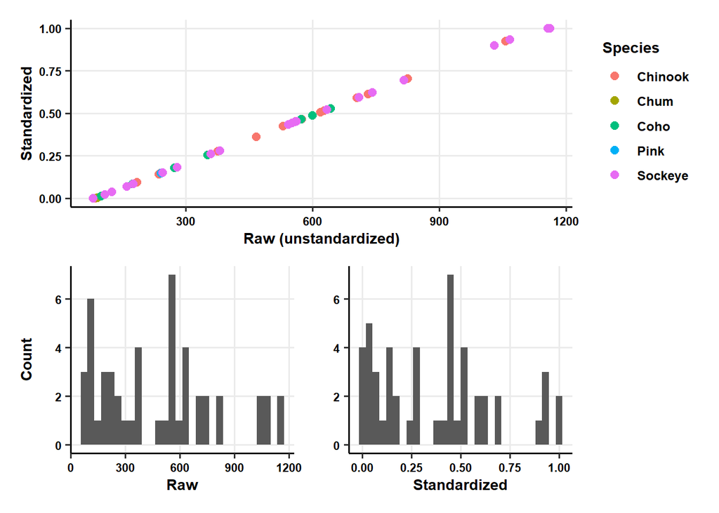

#### 85

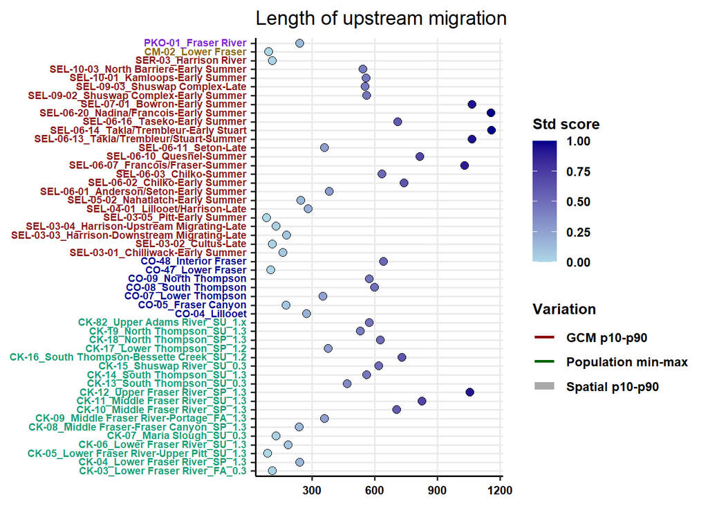

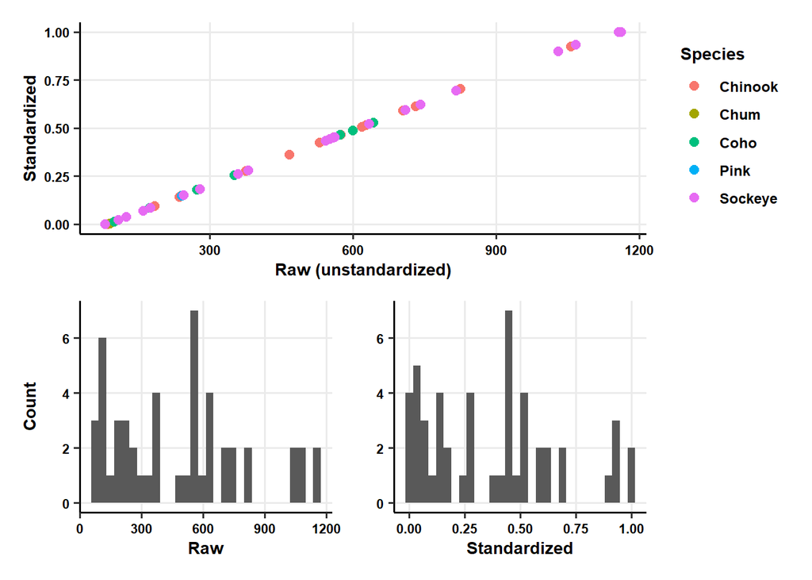

# Demographics

#### Data Sources

**WSP Status Assessments** - Recent assessments for Fraser basin conservation units using methods described in CSAS 2024 [https://www.dfo-mpo.gc.ca/csas-sccs/Publications/ScR-RS/2024/2024_004-eng.html]

#### Methods

Demographic indicators are derived from spawner abundance data and recent Wild Salmon Policy assessments of CU status in the Fraser Basin. The CU status indicator represents the categorical status designation (Red, Amber, Green) using the Rapid Status Assessment Approach in 2022/23 (Pestal et al. 2023). The recent generational average of spawners is derived from the same data set used to assess status and determined based on the geometric average of the number of spawners over the most recent generation with available estimates.

### i. Conservation Status

**Metric:** Recent Wild Salmon Policy (WSP) conservation status of a CU categorized as either Red, Amber, or Green. Status was assessed using the Rapid Status Assessment Approach that uses a Yes/No decision tree considering the number of recent spawners, trends in abundance, data type (absolute or relative abundance), and biological benchmarks (Pestal et al. 2023; CSAS 2024). The input data, thresholds and appropriate metrics, and final status of Fraser CUs in 2022/2023 were evaluated and agreed upon by expert judgement throughout the Rapid Status process.

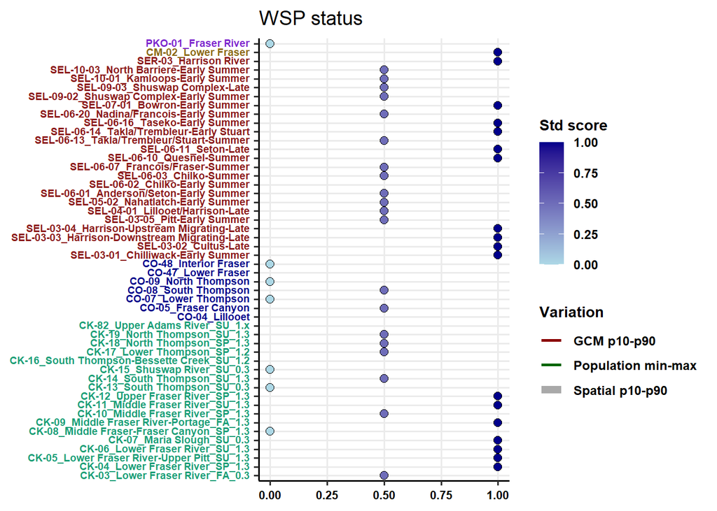

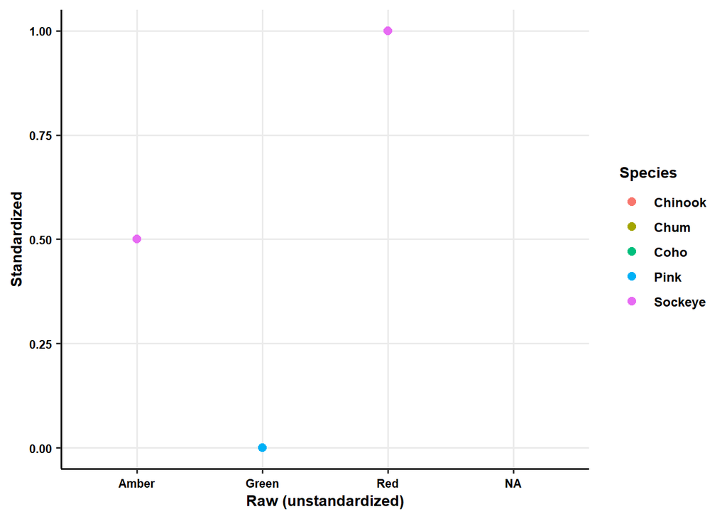

### ii. Recent generational average of spawners (CUnmat)

**Metric:** The geometric average of the number of spawners (male and female) over the most recent generation with available estimates. Sockeye spawners are further refined to only include effective female spawners and not total male and female. For cyclic sockeye CUs where abundance is dominated by a single-year on the cycle line, the number of spawners from the most recent dominant year is used instead of the average over all years of a generation.

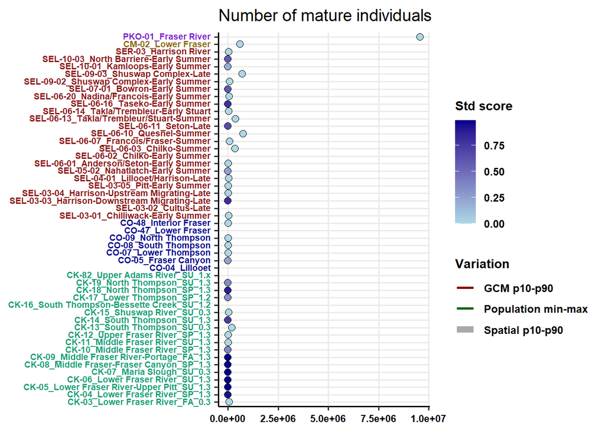

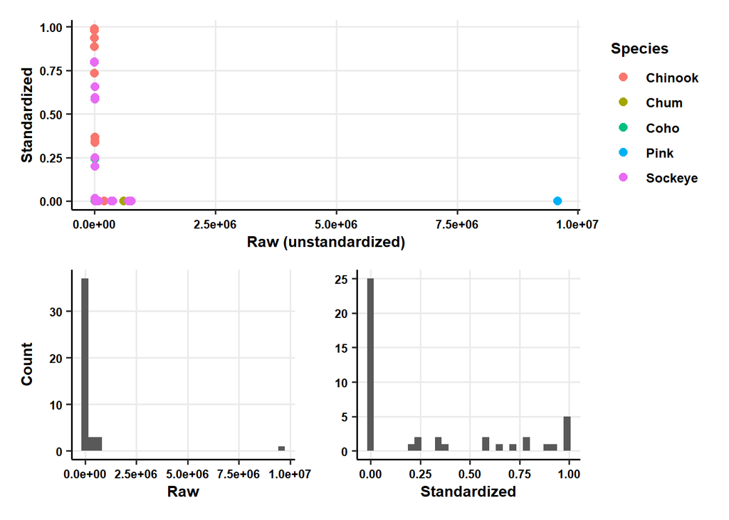

# Nearshore Marine

#### Data Sources

**PSF CU-Specific Life History Timing** - ocean entry timing used to determine projected SST [https://datadryad.org/dataset/doi:10.5061/dryad.wm37pvmwx]

**SST using Quantile Delta Mapping** - CMIP6 earth system model SST values upscaled to a higher resolution using a quantile delta mapping bias correction method. Data set currently in prep for publication by ECCC (Dosser pers comm.).

**Marine Adaptive Zones** - Developed as part of CU definitions by Holtby and Ciruna (2007), adjusted to cover the marine regions.

**HOTSSea -** hindcast of the Salish Sea used for the historical climatology of SST [https://gmd.copernicus.org/articles/18/211/2025/]

**SalishSeaCast** - Regional oceanographic model of the Salish Sea used for projected SST between 2046-2065

**Cumulative Impacts -** Marine habitat cumulative impacts [https://www.dfo-mpo.gc.ca/csas-sccs/Publications/ResDocs-DocRech/2024/2024_024-eng.html]

#### Methods

Marine indicators represent changes to sea surface temperature and cumulative habitat impacts within marine adaptive zones surrounding the period of marine entry for each conservation unit. Sea surface temperature projections from CMIP6 models were averaged for the two months prior peak ocean entry to 2 months following peak ocean entry. Historical climatologies were estimated using the same method but averaged from the HOTSSea model for better representation of historic SSTs.

The spatial domain over which SSTs were averaged was the Strait of Georgia marine adaptive zone. The same spatial domain was applied to all CUs from the Fraser basin as they all share a common ocean entry point.

### i. Projected sea surface temperature near ocean entry

#### 45

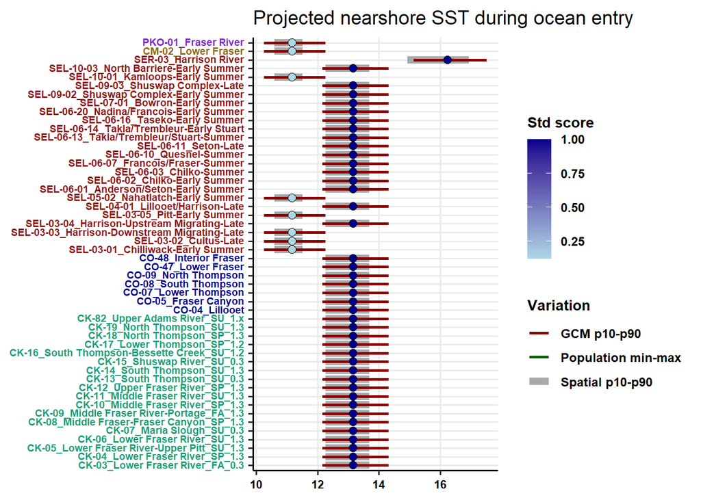

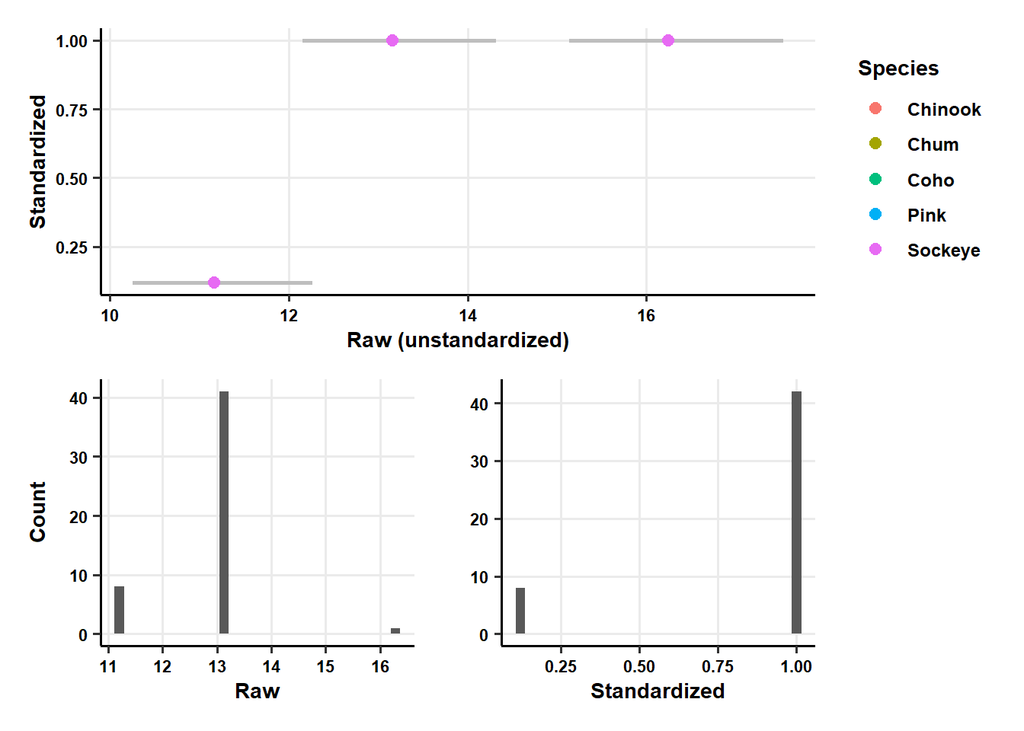

#### 85

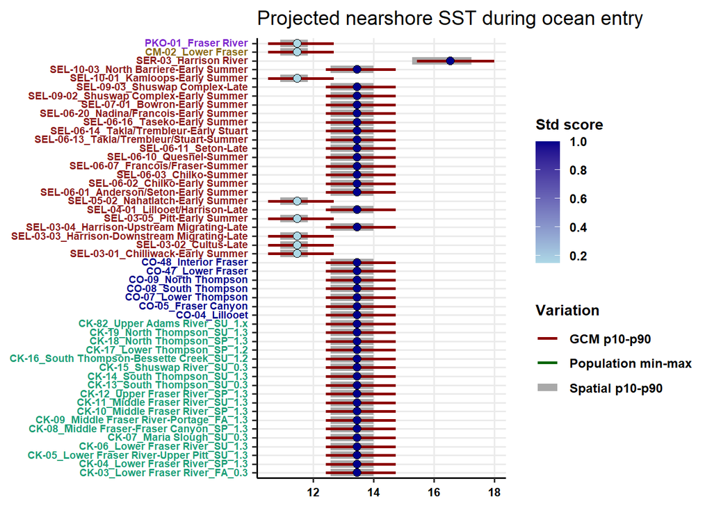

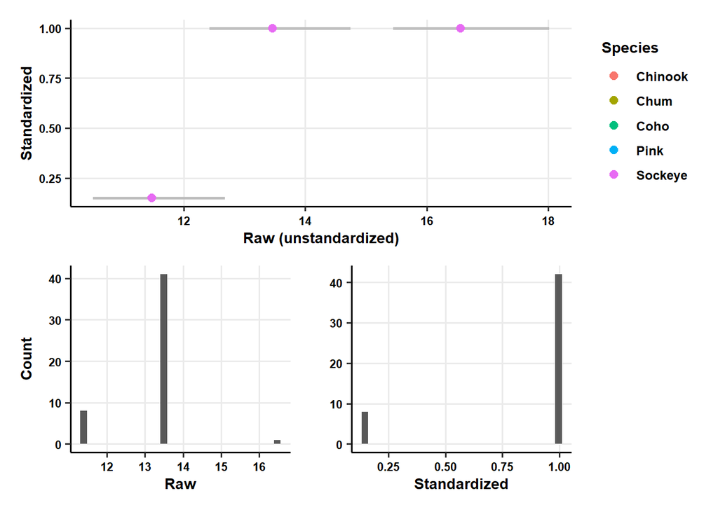

### ii. Rate of change in sea surface temperature near ocean entry

**Metric:** The decadal rate of increase in SST from a baseline period to the projection period (2041-2060 or 2081-2100) throughout the marine adaptive zone (MAZ) for the CU over a 6-month period beginning with the month prior to ocean entry. Projections from RCP 4.5 and 8.5 are included with an ensemble mean calculated from 28 global climate models.

#### 45

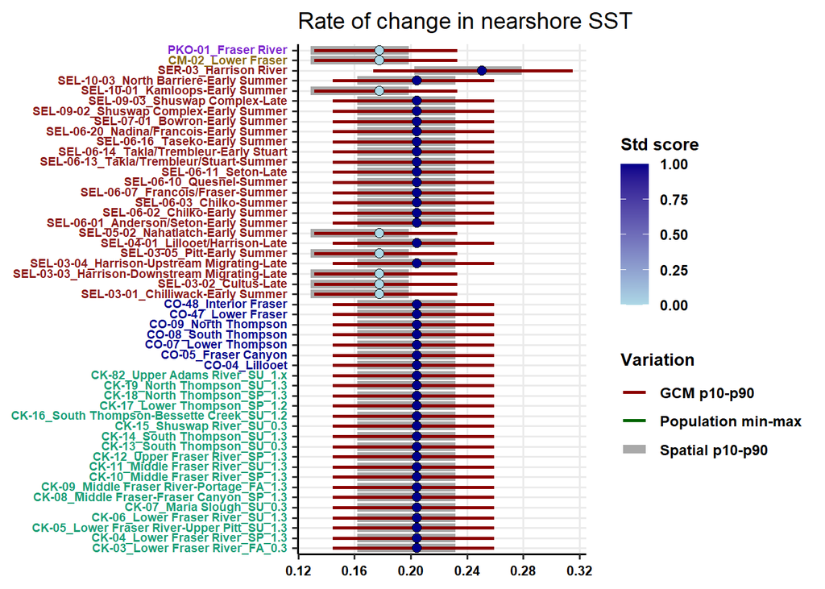

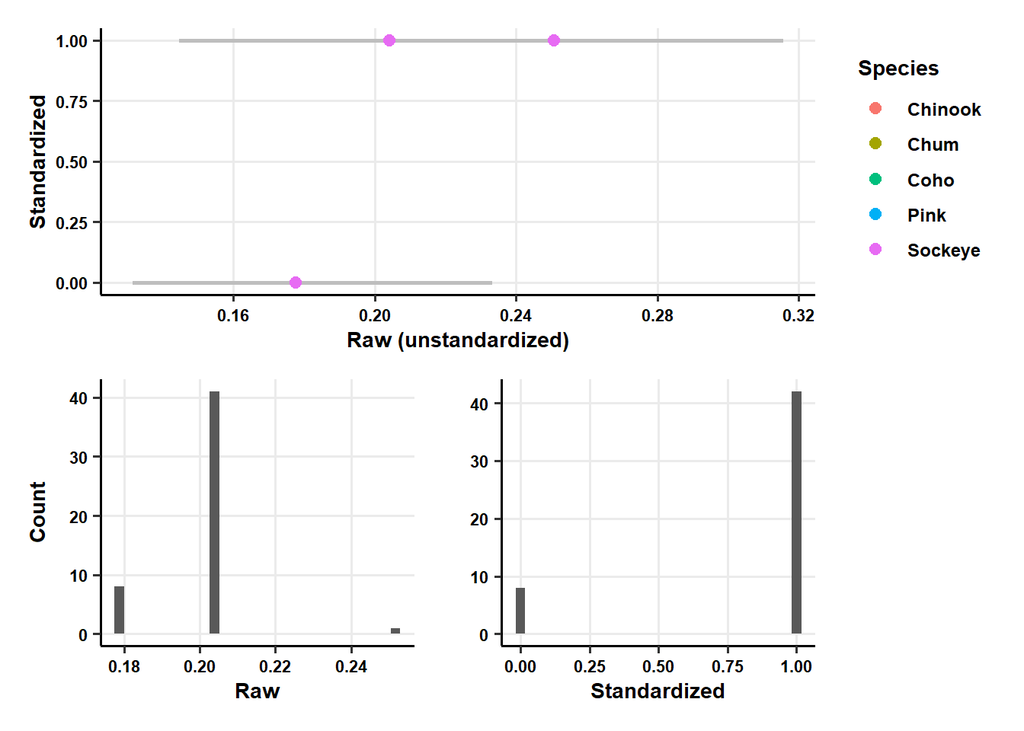

#### 85

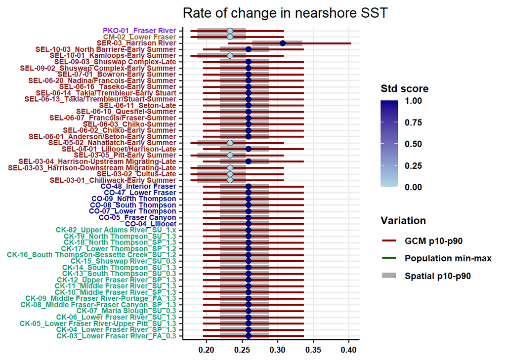

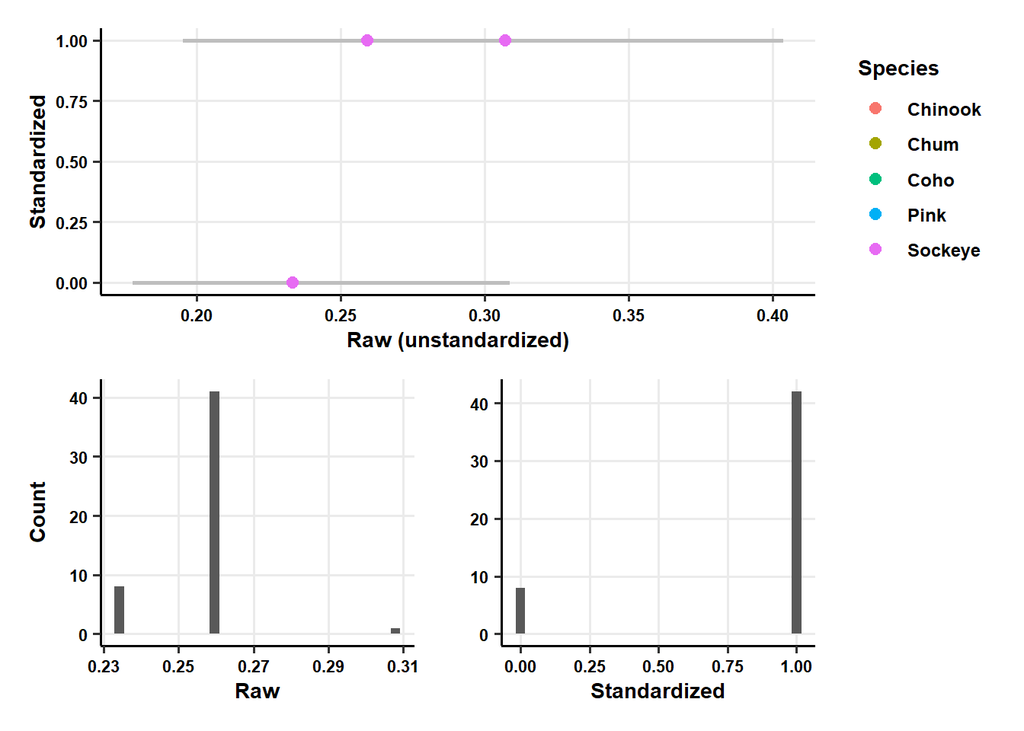

### iii. Cumulative impacts to nearshore marine habitat (CImpact)

**Metric:** The average cumulative impact score of nearshore habitats averaged throughout the MAZ for a CU. Cumulative impact scores are calculated for multiple habitat categories within the Pacific region including pelagic, benthic, eelgrass, and kelp forests. Stressors included as part of the additive cumulative impact model include aquaculture, fishing, invasive species, nutrient inputs, pollution inputs, and shipping (Murray et al. 2024).

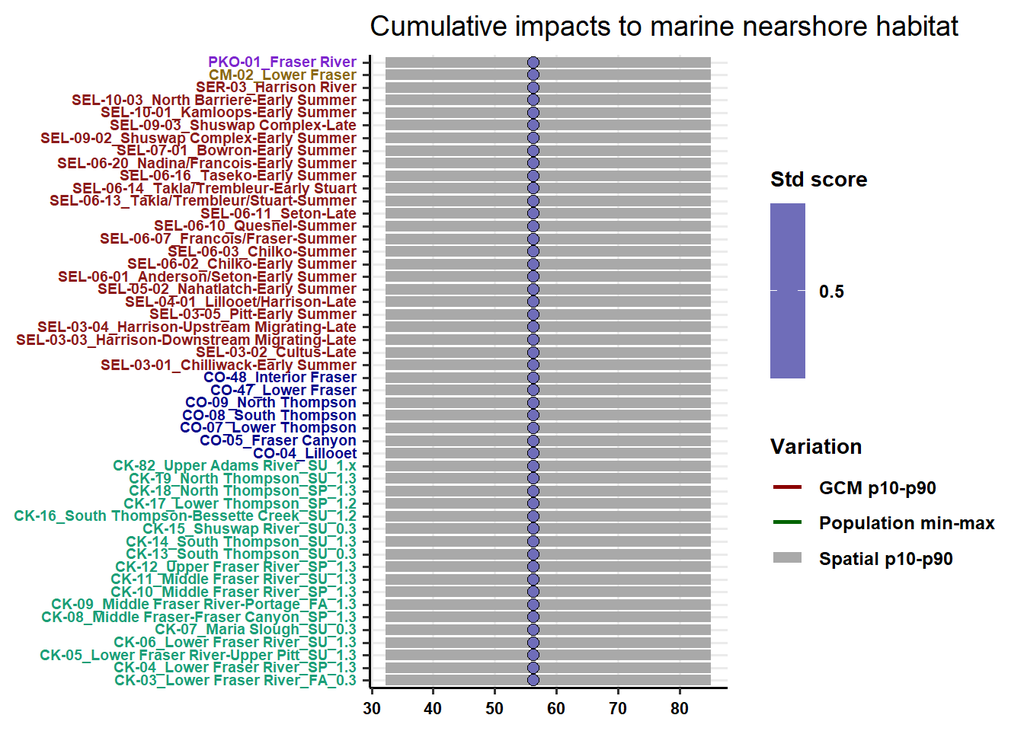

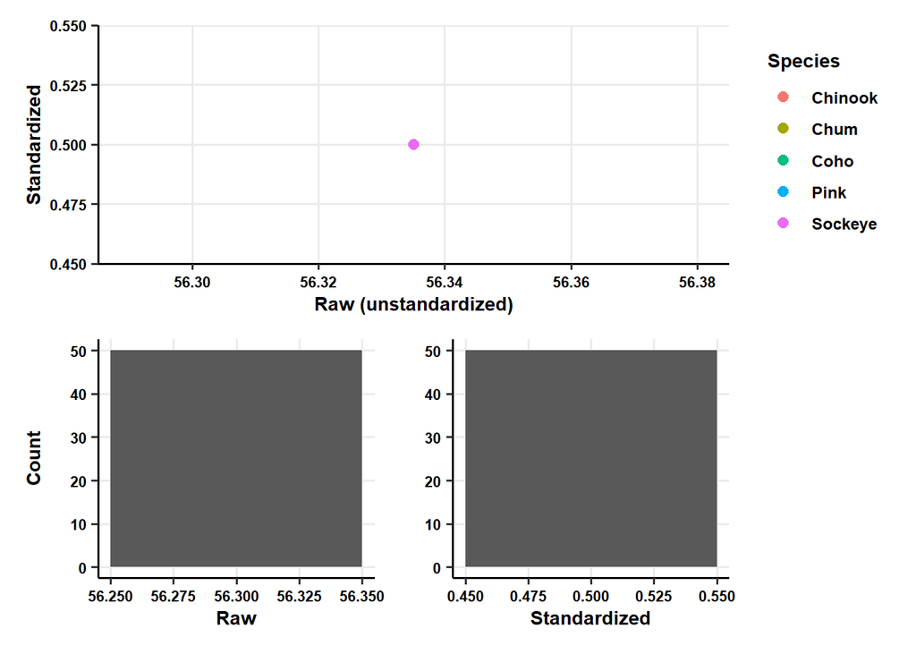

# Genetics

#### Data Sources

**MGL Adaptive Genetic Variation Analysis** - All genetic indicator data was provided by the PBS Molecular Genetics Lab as part of a study on adaptive genetic variation of Pacific salmon (Healy et al, in prep)

#### Methods

Genetic indicators assess the genetic differences among populations across their range to evaluate adaptation potential (heterozygosity) and the differences between current genetic composition and optimal genetic composition under future conditions (genomic offset). The genetic indicators described here come from a genetic analysis of Pacific salmon populations across their North American range, however, only populations within the Fraser basin are currently included. The analysis uses low-coverage sequencing to evaluate genome-wide variation of individuals within populations. For each population, 7-8 individuals were sequenced using samples from the DNA archive of the Pacific Biological Station Genetic Stock Identification program.

Measures of genetic diversity and genomic offset are not comparable across species, therefore, each indicator was standardized based on the range of values within a species, rather than variation across all species used for the other indicators. Genetic indicators are currently available for sockeye and Chinook salmon CUs. Coho salmon will also be added in the future.

### i. Heterozygosity

**Metric:** Heterozygosity is a common metric of genetic diversity within populations that quantifies the proportion of loci that have different alleles, with higher heterozygosity typically indicating greater adaptive potential to changing environmental conditions. Heterozygosity is measured at the individual level as the proportion of heterozygous sites, which are then averaged among all samples to get a population average value. Where multiple populations have been measured, the average across populations is taken to determine the CU heterozygosity.

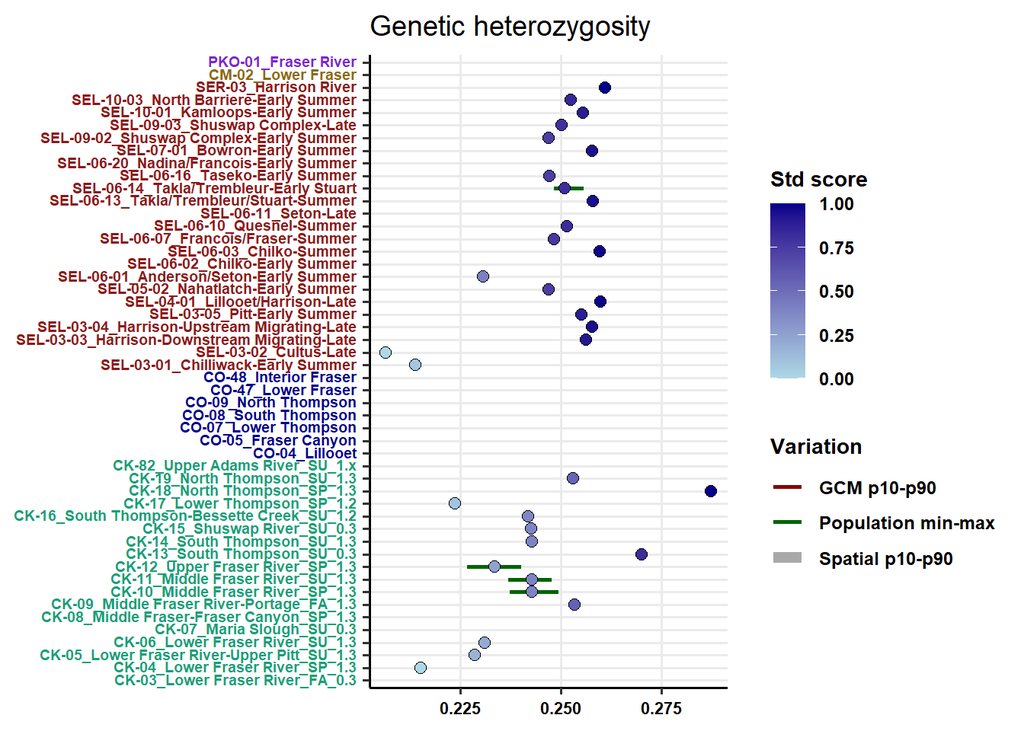

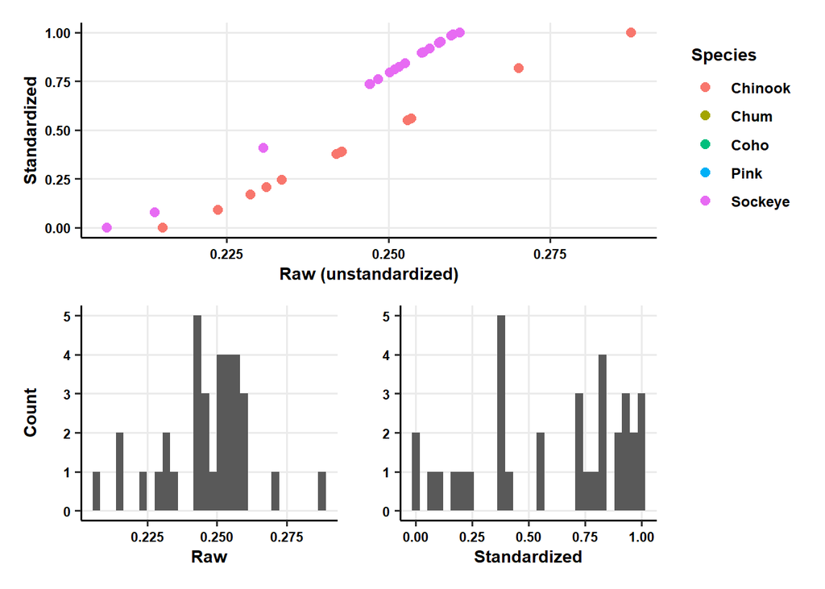

### ii. Genomic offset

**Metric:** The genomic offset is calculated as the Euclidean distance between a population’s current genetic composition and the genetic composition predicted to be optimal under future climate conditions. This distance represents the expected allele frequency change required for the population to track projected climate change, in this case based on average projected air temperatures within CU boundaries under the RCP 8.5 scenario. Where multiple populations have been genotyped within a CU, the average genomic offset of populations was used to provide the indicator value for the CU.

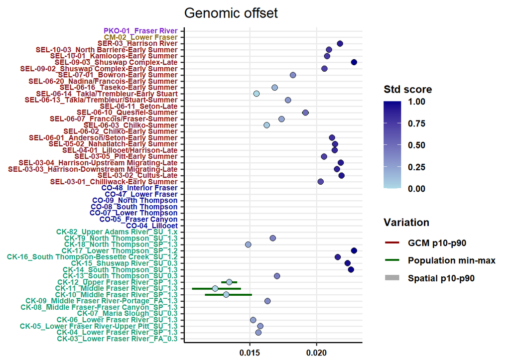

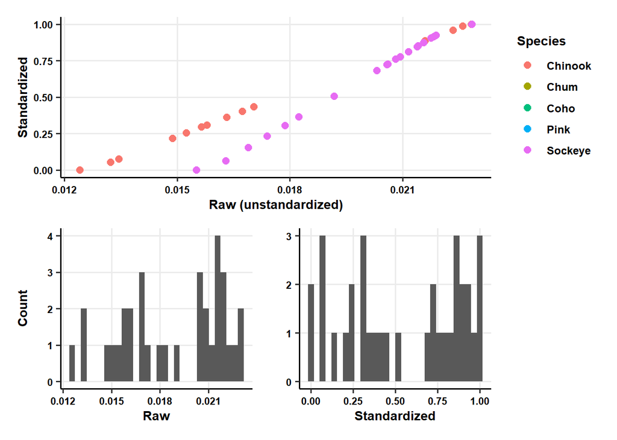

# Overall Vulnerability

### Indicators by category

The following plots show standardized values of indicators across all conservation units. The values are standardized to a 0-1 scale, where 0 is the lowest value and 1 is the highest value for each indicator for each projected time period and emissions scenario.

#### 45

##### Spawning & Rearing exposure indicators

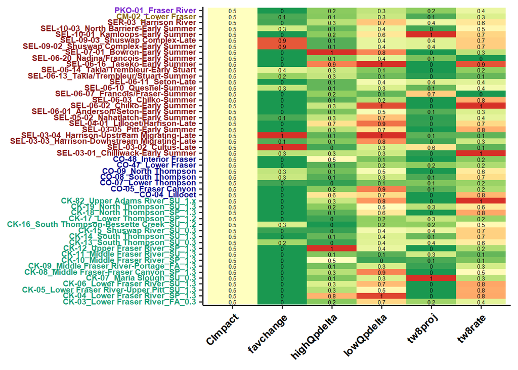

##### Upstream migration indicators

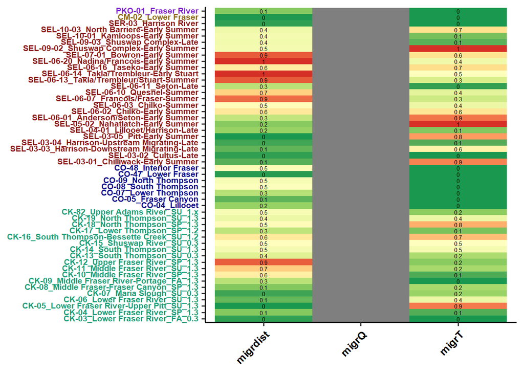

##### Demographic and marine indicators

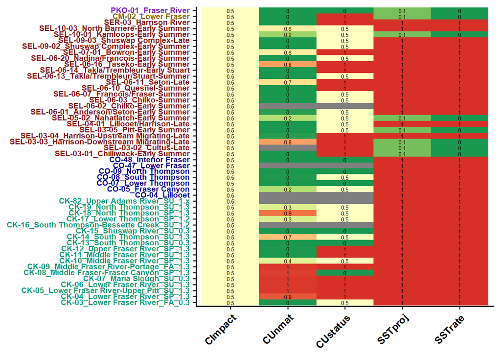

#### 85

##### Spawning & Rearing exposure indicators

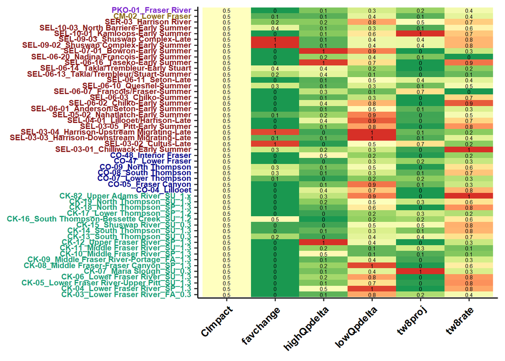

##### Upstream migration indicators

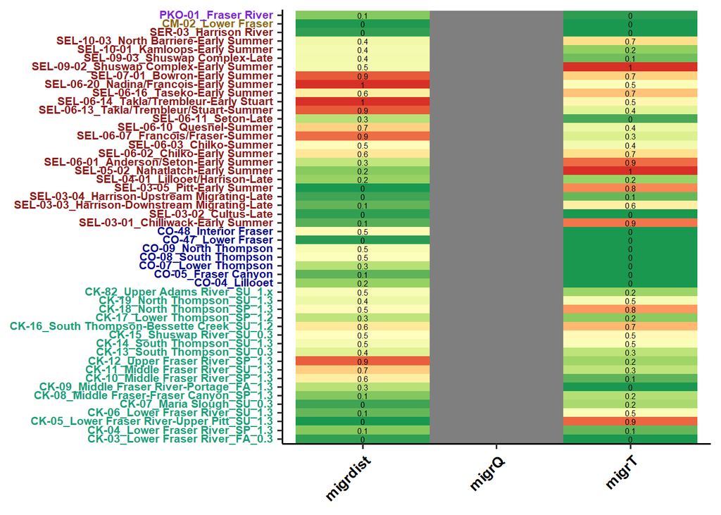

##### Demographic and marine indicators

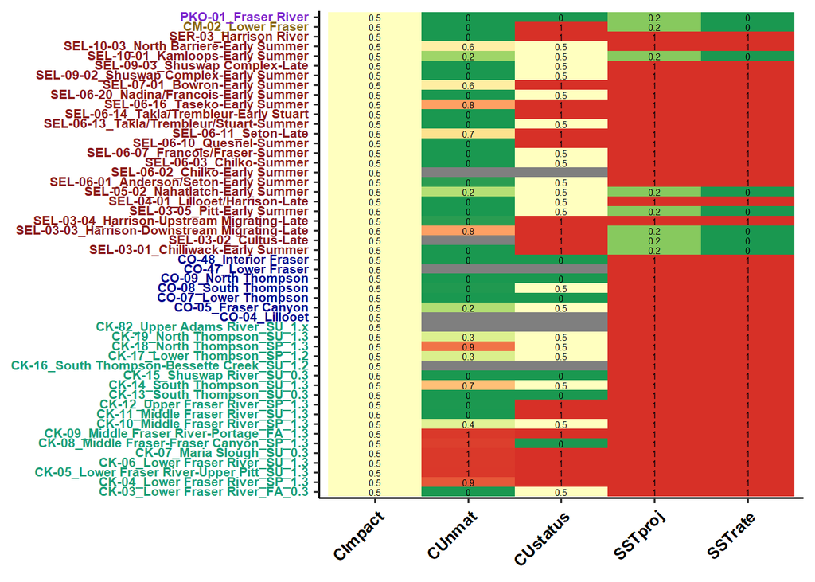

# Sensitivity Analysis

### Correlation of indicators

One test for the utility of an indicator is the correlation with other indicator values. The plot below shows correlation of raw indicator values, where higher correlation among indicators indicates potential overlap in the vulnerability mechanism or information being evaluated.

#### 45

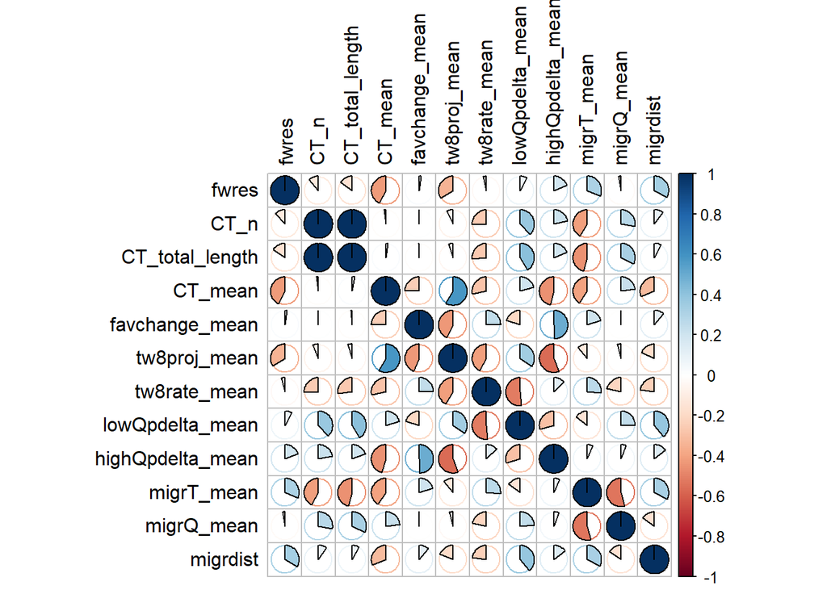

#### 85

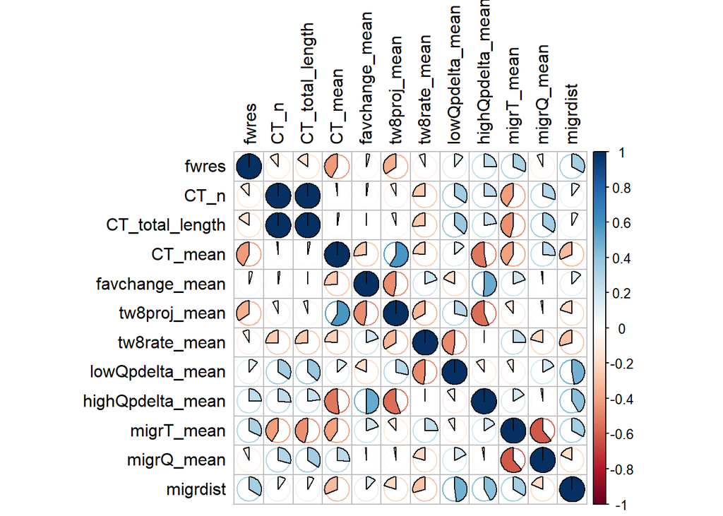

# References

Boyce, Daniel G., Derek P. Tittensor, Cristina Garilao, Stephanie Henson, Kristin Kaschner, Kathleen Kesner-Reyes, Alex Pigot, et al. 2022. “A Climate Risk Index for Marine Life.” *Nature Climate Change* 12 (9): 854–62. https://doi.org/10.1038/s41558-022-01437-y.

Crozier, Lisa G., Michelle M. McClure, Tim Beechie, Steven J. Bograd, David A. Boughton, Mark Carr, Thomas D. Cooney, et al. 2019. “Climate Vulnerability Assessment for Pacific Salmon and Steelhead in the California Current Large Marine Ecosystem.” *PLoS ONE* 14 (7). https://doi.org/10.1371/journal.pone.0217711.

Crozier, Lisa G., and Jared E. Siegel. 2023. “A Comprehensive Review of the Impacts of Climate Change on Salmon: Strengths and Weaknesses of the Literature by Life Stage.” *Fishes* 8 (6). https://doi.org/10.3390/fishes8060319.

CSAS. 2024. “Rapid Status Approximations for Pacific Salmon Derived from Integrated Expert Assessments Under Fisheries and Oceans Canada Wild Salmon Policy” 004.

Dionne, Kaitlyn, Chuck Parken, Lauren Weir, Daniel Doutaz, Richard Bailey, Brittany Jenewein, Kristi Miller-saunders, et al. 2023. “Recovery Potential Assessment for Southern British Columbian Chinook Populations , Fraser and Southern Mainland Chinook.”

Doutaz, Daniel, Ann-marie Huang, Scott Decker, and Tanya Vivian. 2023. *Recovery Potential Assessment for Fraser River Sockeye Salmon (Oncorhynchus Nerka), Nine Designatable Units Part 2: Biology, Habitat, Threats, Mitigations and Allowable Harm - Elements 1-11, 14, 16-18, 22*.

Foden, Wendy B., Stuart H. M. Butchart, Simon N. Stuart, Jean-Christophe Vié, H. Resit Akçakaya, Ariadne Angulo, Lyndon M. DeVantier, et al. 2013. “Identifying the World’s Most Climate Change Vulnerable Species: A Systematic Trait-Based Assessment of All Birds, Amphibians and Corals.” Edited by Sebastien Lavergne. *PLoS ONE* 8 (6): e65427. https://doi.org/10.1371/journal.pone.0065427.

Holtby, L Blair, and Kristine a Ciruna. 2007. “Conservation Units for Pacific Salmon Under the Wild Salmon Policy.” *Can. Sci. Advis. Sec. Res. Doc.* 2007/070: 1–358.

Iacarella, Josephine C, Keegan Paterson, Anna Potapova, and J Daniel Weller. 2025. “Geospatial Indicators and Metrics for Threats to Fish Habitat in the Fraser River Basin with Thompson-Nicola as a Case Study.” *DFO Can. Sci. Advis. Sec. Res. Doc.* 2025/013.

Iacarella, Josephine C., and J. Daniel Weller. 2023. “Predicting Favourable Streams for Anadromous Salmon Spawning and Natal Rearing Under Climate Change.” *Canadian Journal of Fisheries and Aquatic Sciences* 13: 1–13. https://doi.org/10.1139/cjfas-2023-0096.

Murray, Cathryn Clarke, Noreen E Kelly, Jocelyn C Nelson, Grace E.P. Murphy, and Selina Agbayani. 2024. *Cumulative Impact Mapping and Vulnerability of Canadian Marine Ecosystems to Anthropogenic Activities and Stressors*. Ottawa ON: Canadian Science Advisory Secretariat (CSAS).

Pacifici, Michela, Wendy B. Foden, Piero Visconti, James E.M. Watson, Stuart H.M. Butchart, Kit M. Kovacs, Brett R. Scheffers, et al. 2015. “Assessing Species Vulnerability to Climate Change.” *Nature Climate Change* 5 (3): 215–25. https://doi.org/10.1038/nclimate2448.

Peña, M. Angelica, and Isaac Fine. 2024. “Future Physical and Biogeochemical Ocean Conditions Under Climate Change Along the British Columbia Continental Margin.” *Atmosphere-Ocean* 62 (1): 2–23. https://doi.org/10.1080/07055900.2023.2239186.

Pestal, Gottfried, Bronwyn L MacDonald, Sue Grant, and C. A. Holt. 2023. “State of the Salmon: Rapid Status Assessment Approach for Pacific Salmon Under Canada’s Wild Salmon Policy.” *Can. Tech. Rep. Fish. Aquat. Sci.*, no. 3570.

Rangwala, Imtiaz, Wynne Moss, Jane Wolken, Renee Rondeau, Karen Newlon, John Guinotte, and William Riebsame Travis. 2021. “Uncertainty, Complexity and Constraints: How Do We Robustly Assess Biological Responses Under a Rapidly Changing Climate?” *Climate* 9 (12): 1–28. https://doi.org/10.3390/cli9120177.

Urban, M. C., G. Bocedi, A. P. Hendry, J.-B. Mihoub, G. Pe’er, A. Singer, J. R. Bridle, et al. 2016. “Improving the Forecast for Biodiversity Under Climate Change.” *Science* 353 (6304): aad8466. https://doi.org/10.1126/science.aad8466.

Weller, J. Daniel, R. D. Moore, and Josephine C. Iacarella. 2024. “Stream Thermalscape Scenarios for British Columbia, Canada.” *Canadian Water Resources Journal* 49 (2): 233–52. https://doi.org/10.1080/07011784.2023.2267028.

Wilson, Samantha M., and Stephanie J. Peacock. 2025. “Freshwater Life-Cycle Timing of Pacific Salmon and Steelhead ( *Oncorhynchus* Spp.) in Canada.” *Canadian Journal of Fisheries and Aquatic Sciences* 82 (January): 1–17. https://doi.org/10.1139/cjfas-2024-0213.